# Reproducible Research Course Project 1

A. H.

July 3, 2016

### Loading and preprocessing the data

```r
df <- read.csv("activity.csv")
head(df)
```

```
##   steps       date interval
## 1    NA 2012-10-01        0
## 2    NA 2012-10-01        5
## 3    NA 2012-10-01       10
## 4    NA 2012-10-01       15
## 5    NA 2012-10-01       20
## 6    NA 2012-10-01       25
```

```r
df$date <- as.Date(df$date)
```

### Total steps groupped by date

```r
x <- df %>%
        group_by(date) %>%
        summarise(total_steps = sum(steps))
head(x)
```

```
## Source: local data frame [6 x 2]
##
##         date total_steps
## 1 2012-10-01          NA
## 2 2012-10-02         126
## 3 2012-10-03       11352
## 4 2012-10-04       12116
## 5 2012-10-05       13294
## 6 2012-10-06       15420
```

The third column reports the total number of steps taken by an individual in a given day

### Accompanying plot

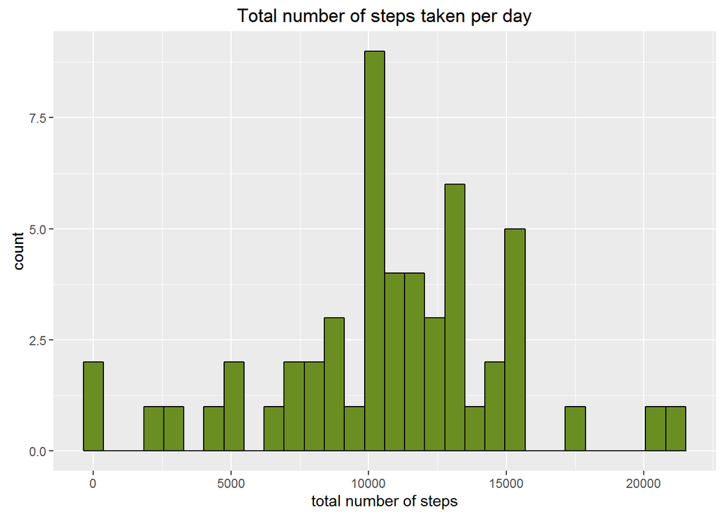

```r
g <- ggplot(x, aes(x=total_steps))
g <- g + labs(title="Total number of steps taken per day", x =("total number of steps"))
g <- g + geom_histogram(na.rm = TRUE, fill = "olivedrab", color = "black")
g
```

The mean and median of the steps taken per day

```r
mean(x$total_steps, na.rm = TRUE)
```

```
## [1] 10766.19
```

```r
median(x$total_steps, na.rm = TRUE)
```

```
## [1] 10765
```

### Activity patterns

Average daily steps

```r
avg_steps <- tapply(df$steps, df$interval, FUN = mean, na.rm = TRUE)
head(avg_steps)
```

```
##         0         5        10        15        20        25
## 1.7169811 0.3396226 0.1320755 0.1509434 0.0754717 2.0943396
```

The formed array shows us the number of average daily steps taken in a specific interval Create a dataframe of values that is going to help us construct the plot

```r
y <- data.frame(
        interval = as.numeric(names(avg_steps)),
        steps = avg_steps,
        row.names = NULL
        )
head(y)
```

```
##   interval     steps
## 1        0 1.7169811
## 2        5 0.3396226
## 3       10 0.1320755
## 4       15 0.1509434
## 5       20 0.0754717
## 6       25 2.0943396
```

Plot of average daily activity.

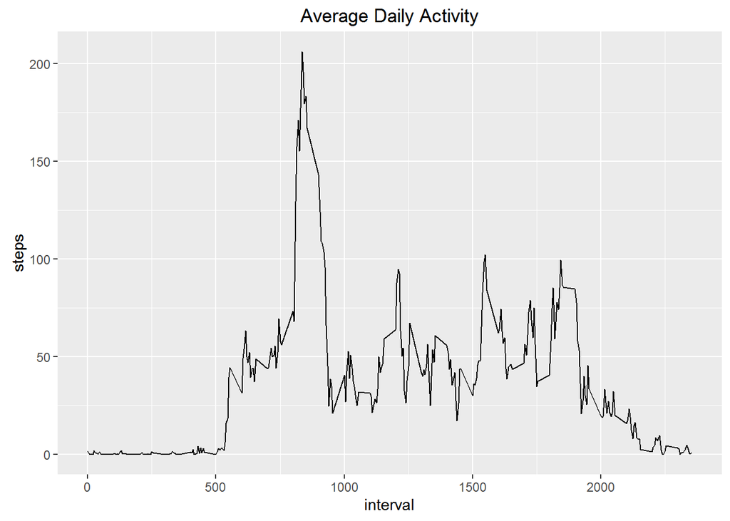

```r
qplot(data = y, x=interval, y= steps, geom = "line", main = "Average Daily Activity")
```

We can clearly see a spike in the morning and very little activity during night hours The maximum number of steps across all the days in the dataset are taken during 8:35 AM

```r
subset(y, steps == max(y$steps))
```

```
##     interval    steps
## 104      835 206.1698
```

## Missing values

Total number of rows with NAs is **2304**

```r
table(is.na(df$steps))
```

```
##
## FALSE  TRUE
## 15264  2304
```

```r
df2 <- replace(df$steps, list = which(is.na(df$steps) == TRUE), values = y$steps)
head(df2)
```

```
## [1] 1.7169811 0.3396226 0.1320755 0.1509434 0.0754717 2.0943396
```

### Ceating a new dataset with the missing data filled in.

Here, we use the average daily steps for each interval across all days

```r
df2 <- data.frame(date = df$date, interval = df$interval, steps = df2)
head(df2)
```

```
##         date interval     steps
## 1 2012-10-01        0 1.7169811
## 2 2012-10-01        5 0.3396226
## 3 2012-10-01       10 0.1320755
## 4 2012-10-01       15 0.1509434
## 5 2012-10-01       20 0.0754717
## 6 2012-10-01       25 2.0943396
```

### A histogram of the total number of steps taken each day

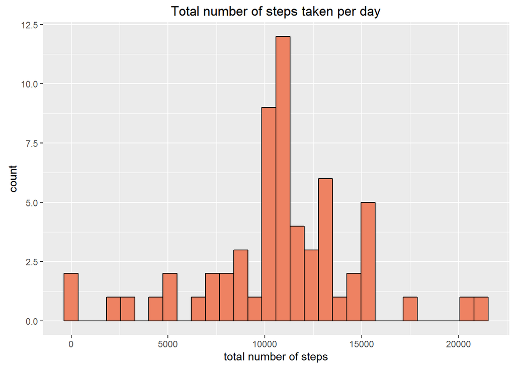

```r
x2 <- df2 %>%
        group_by(date) %>%
        summarise(total_steps = sum(steps))

g <- ggplot(x2, aes(x=total_steps))
g <- g + labs(title="Total number of steps taken per day", x =("total number of steps"))
g <- g + geom_histogram(fill = "salmon2", color = "black")
g
```

### Mean and median values

```r
mean(x2$total_steps)
```

```
## [1] 10766.19
```

```r
median(x2$total_steps)
```

```
## [1] 10766.19
```

It should not be surprising to see very similar values for mean & average steps because we specifically included the averaged values for each interval. We also see a higher frequency of occurence of the number of steps.

### Weekdays v. weekends

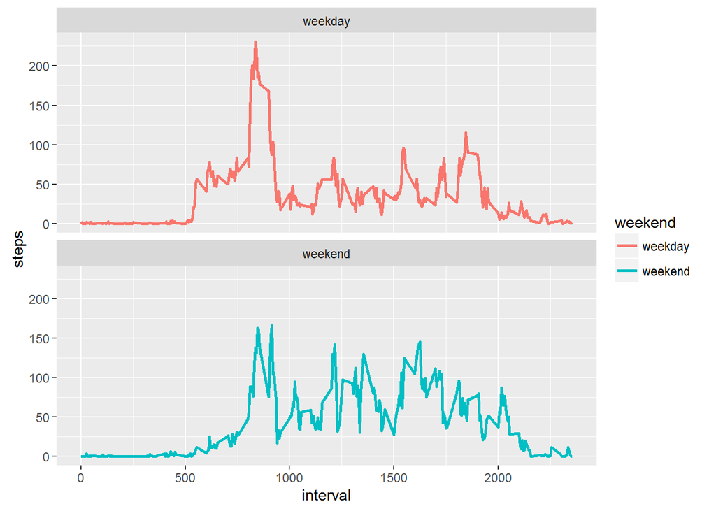

```r
df2$days <- weekdays(df2$date, abbreviate = TRUE)

df2$weekend <- as.factor(ifelse(df2$days == "Sat" | df2$days == "Sun", "weekend", "weekday"))

g <- ggplot(data = df2, aes(interval, steps, color = weekend))
g <- g + facet_wrap( ~ weekend, nrow = 2)
g <- g + stat_summary(fun.y="mean", geom="line", lwd = 1, aes(group=1))
g
```